EPOL 590 · AI and Academic Literature · Lecture 3

# Literature Workbench

Read an article closely, follow the literature around it, and map the field it belongs to — noticing, at each step, what AI changes.

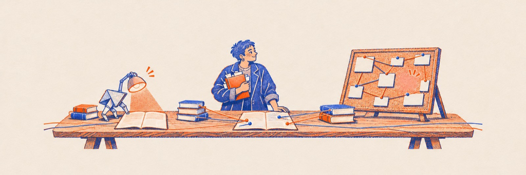

## What this is for

Tonight you will read one article closely, follow the literature around it, and map the field it belongs to. The point is not to produce summaries faster. It is to notice how scholarly arguments are built, what different traditions count as evidence, and whether AI preserves those differences or flattens them into a generic template.

The workbench is a scratchpad for that work. It keeps your reading notes, your discovery log and your map side by side, so you can see how a reading turns into a search and a search into a map. Your group's **Google Doc remains the shared record**: copy into it from here.

### Seed articles

**Group A · humanities / critical studies.** Smart et al. (2026), “Toward a Theory of Value in AI Alignment,” arXiv:2608.10327 (preprint). The authors annotated 94 alignment papers to recover their theory of value. [Article](https://arxiv.org/abs/2608.10327)

**Group B · computer science.** Sharma et al. (2024), “Towards Understanding Sycophancy in Language Models,” ICLR 2024. Read the main paper; the appendices are optional. [Article](https://arxiv.org/abs/2310.13548)

Both are open access under CC BY 4.0, so you may download them, share them and upload them to AI tools. Check the licence of anything else before uploading it.

Hour 1 · 5:15–6:20

### 1 · Read

Read your group's article by one strategy — sequential, overview-first or investigative — *without AI first*. Record the claim, warrant, uncertainty and your path. Then ask AI to follow the same route and record what changed. Finish with a handover brief.

Hour 2 · 6:30–7:15

### 2 · Search

Take the other group's article and brief. Trace its literature backward, forward and sideways, first conventionally and then with AI. Verify every reference before you log it as verified. No gap-hunting yet.

Hour 3 · 7:15–7:50

### 3 · Map

Map your original article's field, then look at it three ways: conceptual, chronological and relational. Exchange maps, critique, revise — and save each version with your reason for changing it.

### Ground rules

- **Human first.** Read before you prompt.
- **AI follows your route.** Ask it to read the way you read, then compare.
- **Every citation is a lead, not a source,** until you have found it and checked it says what is claimed.
- **A gap in the map may be a gap in your search** or in how you drew it, not in the field.

### Your data

Everything stays in this browser. Nothing is uploaded to Machine Spirits, and the workbench never calls an AI service — use a permitted tool such as NotebookLM or Gemini alongside it.

Download a project file to keep your work. On a shared computer, use *Save & export → Clear all* before you leave.

Supports Hour 1

## PDF shelf

Open permitted PDFs here to read and quote them with page references. Text extraction happens in this browser; files are not uploaded anywhere. The first extraction needs an internet connection to load the PDF.js library.

Choose PDF files

No PDFs loaded.

Current document

Highlight text in an extracted page below, then send it. It is added to the Warrant field with its page reference.

Find a phrase in extracted text

### Document viewer

[interactive chart not shown]

Scanned PDFs without selectable text need OCR, which is not included. Publisher licences and institutional data rules still apply.

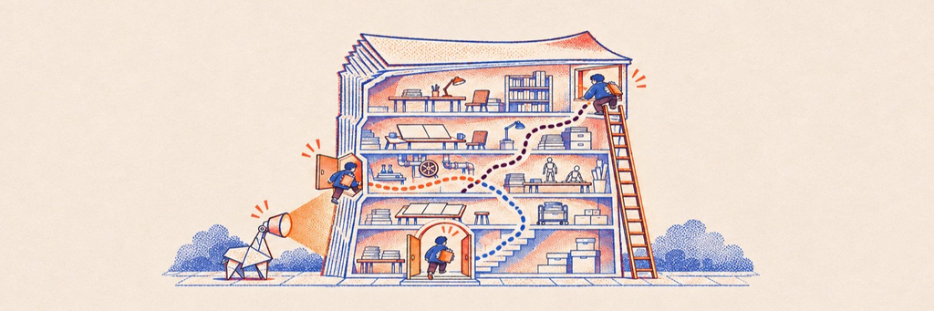

Hour 1 · 5:15–6:20

## 1 · Read

Read by one strategy and note where you started and what you skipped. Fill in the record without AI first; then ask AI to follow the *same* route, paste what it says, and record what changed.

### Reading record

Article Reading strategy Reading path: where did you start, and what did you skip? Claim: what is the paper trying to persuade readers to believe? Warrant: evidence, reasoning, method or examples, with a passage or section reference Uncertainty: what remains unclear or unconvincing? AI reading that followed the same strategy (paste) What changed when AI followed your path?

### Prompt for your strategy

Supply the actual article. If your tool only has an excerpt, tell it to limit its claims to that excerpt.

### Compare reading records

Which disagreement comes from the article, and which from where we entered it? Did AI preserve or flatten the discipline's standards of evidence?

6:15–6:20

### Handover brief

For the group that searches outward from your article after the break.

Central claim Unresolved question 1 Unresolved question 2 One promising reference Source passage(s)

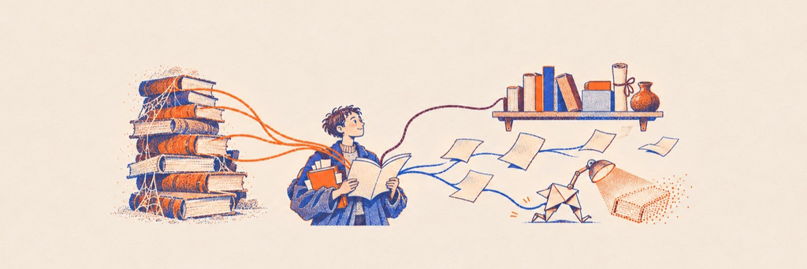

Hour 2 · 6:30–7:15

## 2 · Search

Start from the other group's brief. Follow references **backward**, citing work **forward**, and dissenting or adjacent work **sideways** — conventionally first, then with AI. An AI-suggested reference is unverified until you have found it and read enough to confirm it says what is claimed.

### Log a source

Publication title Author and year Source URL or DOI

Direction

Found by

Verification Significance to the original article

### Discovery log

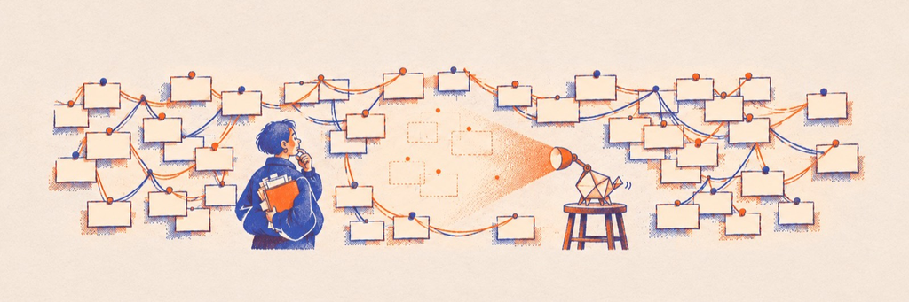

Hour 3 · 7:15–7:50

## 3 · Map

Map your original article's field using your reading and the other group's discoveries. Then change the view: each one foregrounds something different and hides something else. Before calling an empty region a gap in the field, ask whether it is a gap in your search or in your drawing.

ConceptPublication

### Add to the map

Concept or publication

Type

Year (for the timeline)

### Connect

From

To

Relationship

### Possible gaps

What is missing or uncertain — and how would you check?

7:40–7:46

### Versions

Save the map before and after you revise it, with your reason. The difference between versions is part of your answer.

Why this version?

## Save & export

### Keep your work

Everything is saved in this browser's local storage. Download a project file before changing devices or clearing browser data, and import it to carry on.

Import a project file

### Shared computer?

Clear all removes your readings, sources, map and versions from this browser.

### Make it yours

This workbench is a single HTML file with no server. Download it, open it offline, and change it with a text editor, Claude Code or another coding agent.

PDF text extraction loads PDF.js from the internet. AI integration, OCR and shared group syncing are not implemented. PDFs stay in memory and must be reselected after a reload.